# Explore spatially-derived variables for culvert work sites

B. Van Deynze

Aug. 18th, 2020

This document summarizes spatially-derived variables for PNSHP culvert work sites. These variables are collected by linking the work site points to other spatial data sets via polygon covers or identifying the nearest line. As of right now, we have data from Blake on roads, streams, habitat use, slope, and land cover. I also have collected some county-level data on employment levels in relevant sectors.

## Evaluating accuracy of stream and road matches

First thing we’ll do is check how accurate the culvert work site points match up with the road and stream data recovered from three sources: (1) [HERE](https://gii.dhs.gov/hifld/sites/default/files/2019-08/HIFLD%20Licensed%20HERE%20One%20Pager.pdf) for network-able road features, (2) [NHDPlus HR](https://hydro.nationalmap.gov/arcgis/rest/services/NHDPlus_HR/MapServer) for stream/river classification and features, (3) [StreamNet](https://www.streamnet.org/data/interactive-maps-and-gis-data/) for salmonid habitat use data by species. We will evaluate the precision of matches using distance to the “matching” line, measured in meters.

We suspect two possible sources of imprecision. First, work site points may be reported with imprecision, in which case the match would represent the most likely feature, but with less certainty than if distance was lower. Second, the work site may be on a road or stream that is not represented in our source data. In this case, the matched feature would misrepresent the true feature we are trying to identify for the work site.

In either case, we will need to identify and decide how to deal with “poor” matches. For now, we will define poor matches as work sites over 150m from the target feature (i.e. road or stream), represented in the figures below with a red horizontal line.

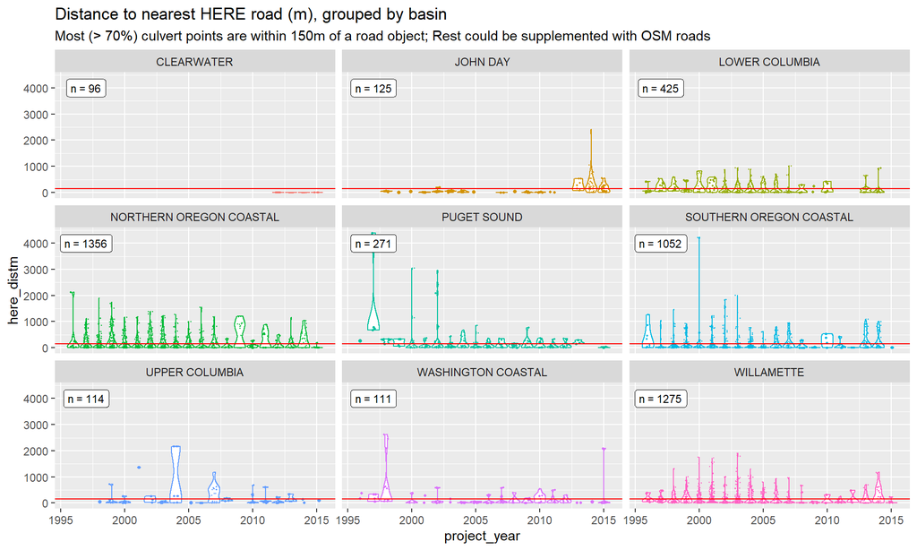

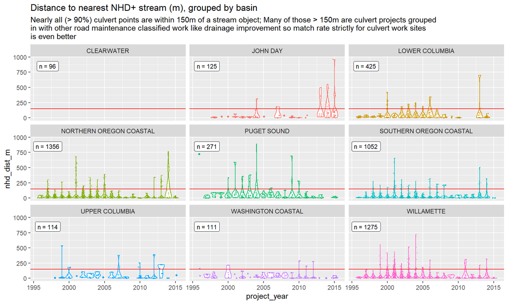

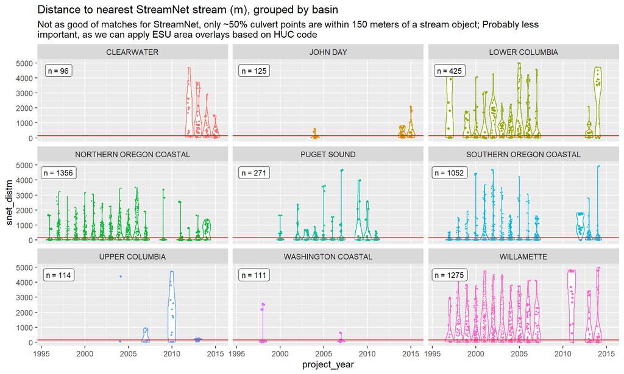

So StreamNet’s less dense streams have the worst matches, while NHD+ has very close matches. StreamNet is most useful for salmon habitat identification, though HUC code based habitat maps can be used instead (e.g. maps seen in [Crozier et al. 2018](https://journals.plos.org/plosone/article?id=10.1371/journal.pone.0217711)).

The HERE roads have lots of close matches, but also plenty that are far off the mark. We can supplement with [OpenStreetMaps (OSM)](https://wiki.openstreetmap.org/wiki/Main_Page) road data, which appears to be more dense than the HERE network.

## Examine road features

The HERE data provides variables for *speed class*, *class*, *paved*, and *public*. Paved status, speed class, and road type are potential cost drivers. Plots for all three are provided below.

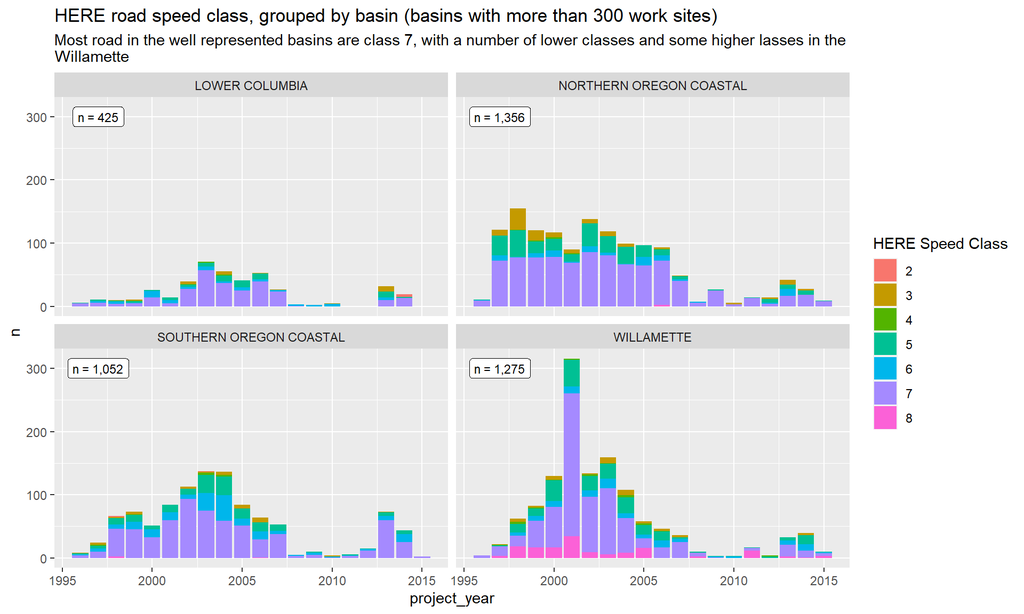

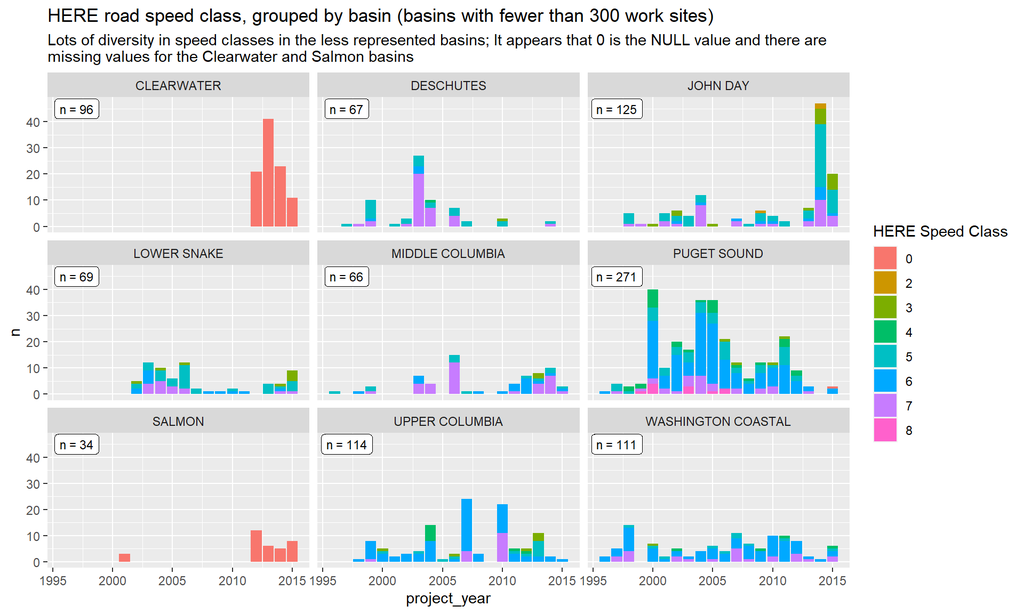

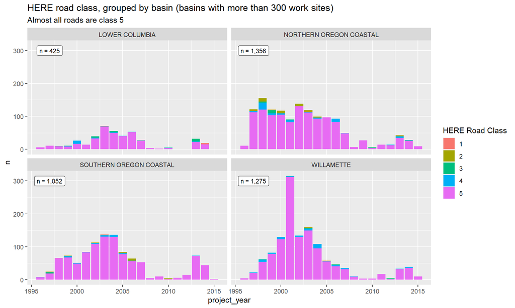

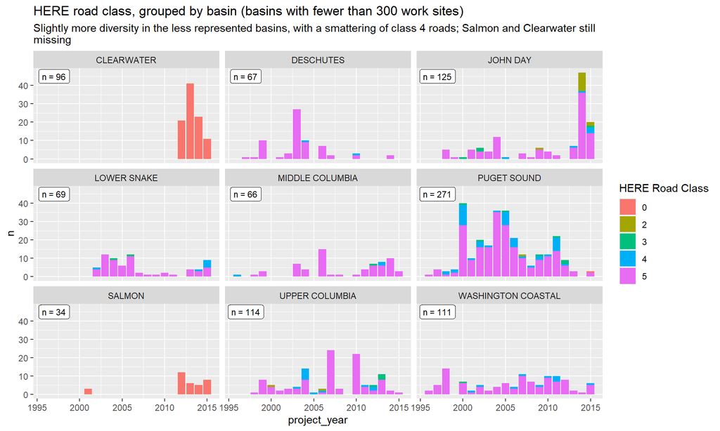

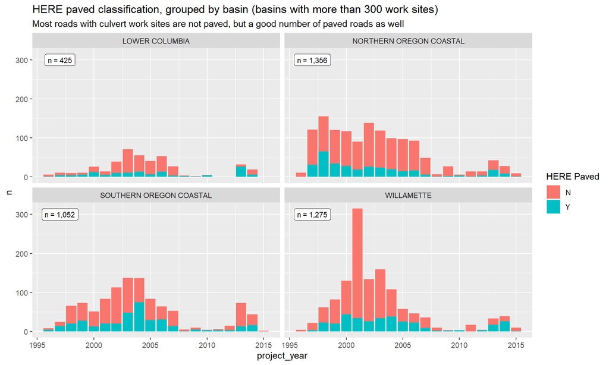

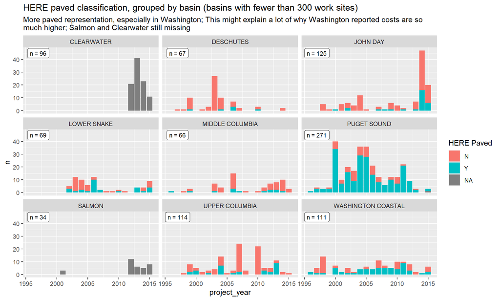

## Salmon use of streams with work sites

The StreamNet data provides variables for *species* and *habitat use*. These variables will be valuable for modeling benefits of culvert improvement, but may also lead to stricter design requirements if in the habitat of ESA listed species.

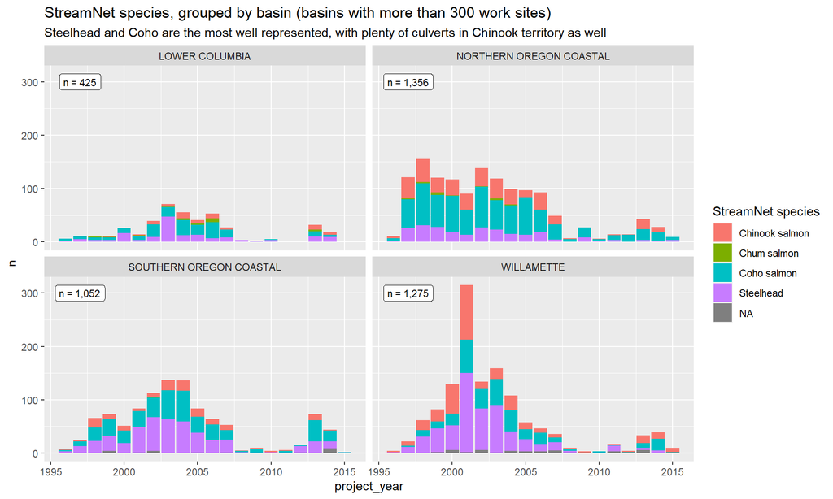

[figure not shown]

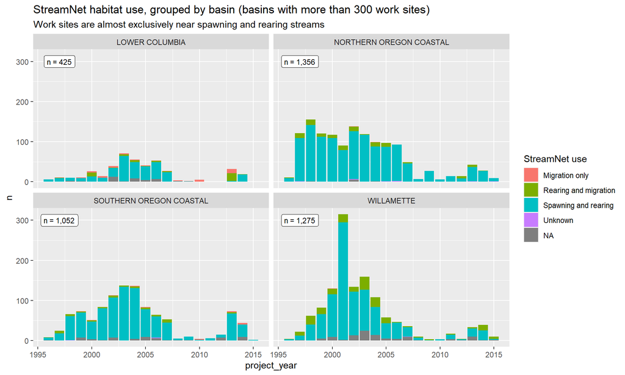

[figure not shown]

Key takeaway is that the culverts projects in Washington and Oregon are on distinctly different streams. In Washington, reported projects are more frequently on migration streams. These streams are likely to open up more upstream territory, but may also be wider and require more complex culvert designs. In Oregon, the reported projects are overwhelmingly on spawning and rearing streams, which (I believe) tend to be smaller and therefore woud require less complex designs.

## Slope at work site

The slope at the work site may increase project cost by restricting access to the culvert or by requiring a more complex culvert design. We measure slope using the slope in degrees of the [GTOPO30](https://www.usgs.gov/centers/eros/science/usgs-eros-archive-digital-elevation-global-30-arc-second-elevation-gtopo30?qt-science_center_objects=0#qt-science_center_objects) grid cell the work site falls in.

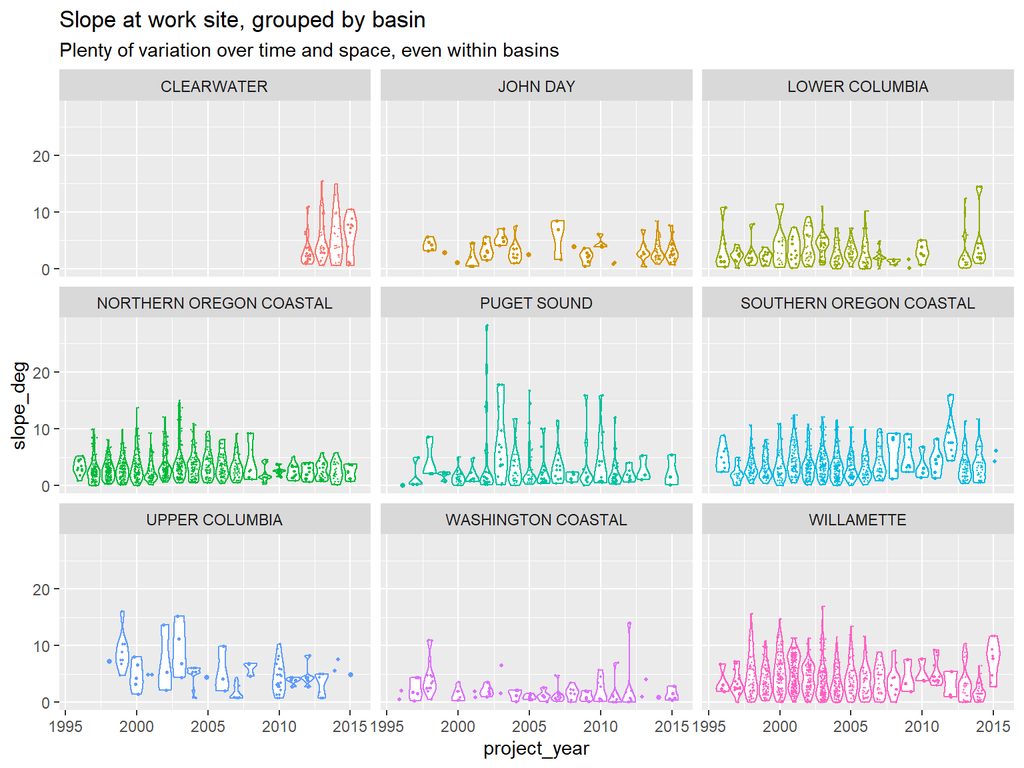

## Land cover at work sites

Land cover can proxy for land use, which can effect how difficult it is to access and perform construction activities at the work site, which may increase costs. It may also be correlated with road features (surface material, typical traffic, etc.) or stream features, and could be useful for providing more information for work sites where matches to roads and streams are poor.

The table below presents the NLCD land cover classifications. We use the “class” level of detail in the figures that follow.

| class | value | classification | description |
| --- | --- | --- | --- |
| Barren | 31 | Barren Land (Rock/Sand/Clay) | areas of bedrock, desert pavement, scarps, talus, slides, volcanic material, glacial debris, sand dunes, strip mines, gravel pits and other accumulations of earthen material. Generally, vegetation acc… |
| Developed | 21 | Developed, Open Space | areas with a mixture of some constructed materials, but mostly vegetation in the form of lawn grasses. Impervious surfaces account for less than 20% of total cover. These areas most commonly include l… |
| Developed | 22 | Developed, Low Intensity | areas with a mixture of constructed materials and vegetation. Impervious surfaces account for 20% to 49% percent of total cover. These areas most commonly include single-family housing units. |
| Developed | 23 | Developed, Medium Intensity | areas with a mixture of constructed materials and vegetation. Impervious surfaces account for 50% to 79% of the total cover. These areas most commonly include single-family housing units. |
| Developed | 24 | Developed High Intensity | highly developed areas where people reside or work in high numbers. Examples include apartment complexes, row houses and commercial/industrial. Impervious surfaces account for 80% to 100% of the total… |
| Forest | 41 | Deciduous Forest | areas dominated by trees generally greater than 5 meters tall, and greater than 20% of total vegetation cover. More than 75% of the tree species shed foliage simultaneously in response to seasonal cha… |
| Forest | 42 | Evergreen Forest | areas dominated by trees generally greater than 5 meters tall, and greater than 20% of total vegetation cover. More than 75% of the tree species maintain their leaves all year. Canopy is never without… |
| Forest | 43 | Mixed Forest | areas dominated by trees generally greater than 5 meters tall, and greater than 20% of total vegetation cover. Neither deciduous nor evergreen species are greater than 75% of total tree cover. |
| Herbaceous | 71 | Grassland/Herbaceous | areas dominated by gramanoid or herbaceous vegetation, generally greater than 80% of total vegetation. These areas are not subject to intensive management such as tilling, but can be utilized for graz… |
| Herbaceous | 72 | Sedge/Herbaceous | Alaska only areas dominated by sedges and forbs, generally greater than 80% of total vegetation. This type can occur with significant other grasses or other grass like plants, and includes sedge tundr… |
| Herbaceous | 73 | Lichens | Alaska only areas dominated by fruticose or foliose lichens generally greater than 80% of total vegetation. |
| Herbaceous | 74 | Moss | Alaska only areas dominated by mosses, generally greater than 80% of total vegetation. |
| Planted-Cultivated | 81 | Pasture/Hay-areas of grasses, legumes, or grass | legume mixtures planted for livestock grazing or the production of seed or hay crops, typically on a perennial cycle. Pasture/hay vegetation accounts for greater than 20% of total vegetation. |
| Planted-Cultivated | 82 | Cultivated Crops | areas used for the production of annual crops, such as corn, soybeans, vegetables, tobacco, and cotton, and also perennial woody crops such as orchards and vineyards. Crop vegetation accounts for grea… |
| Shrubland | 51 | Dwarf Scrub | Alaska only areas dominated by shrubs less than 20 centimeters tall with shrub canopy typically greater than 20% of total vegetation. This type is often co-associated with grasses, sedges, herbs, and … |
| Shrubland | 52 | Shrub/Scrub | areas dominated by shrubs; less than 5 meters tall with shrub canopy typically greater than 20% of total vegetation. This class includes true shrubs, young trees in an early successional stage or tree… |
| Water | 11 | Open Water | areas of open water, generally with less than 25% cover of vegetation or soil. |
| Water | 12 | Perennial Ice/Snow | areas characterized by a perennial cover of ice and/or snow, generally greater than 25% of total cover. |
| Wetlands | 90 | Woody Wetlands | areas where forest or shrubland vegetation accounts for greater than 20% of vegetative cover and the soil or substrate is periodically saturated with or covered with water. |
| Wetlands | 95 | Emergent Herbaceous Wetlands | Areas where perennial herbaceous vegetation accounts for greater than 80% of vegetative cover and the soil or substrate is periodically saturated with or covered with water. |

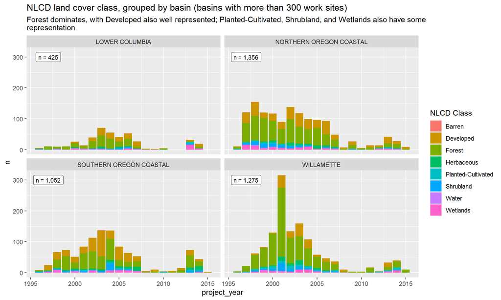

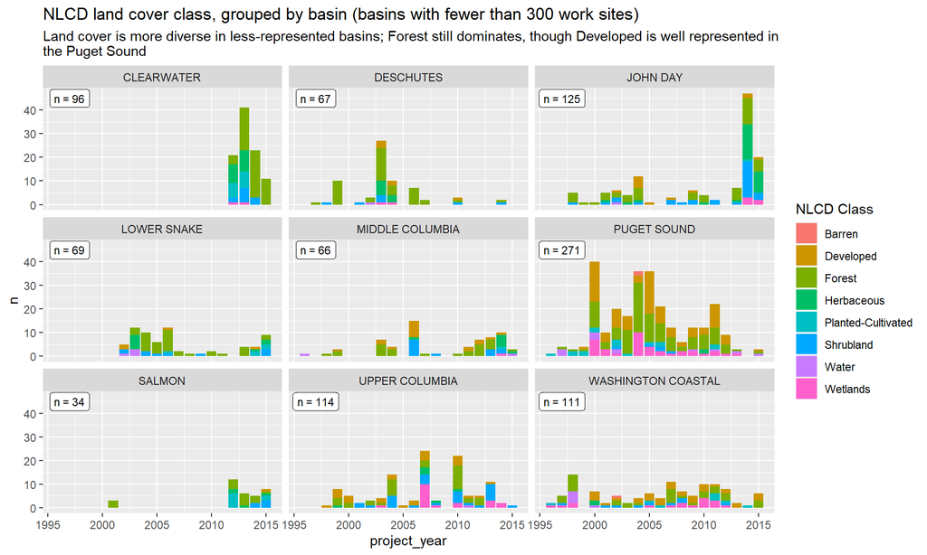

## Job shares in relevant sectors

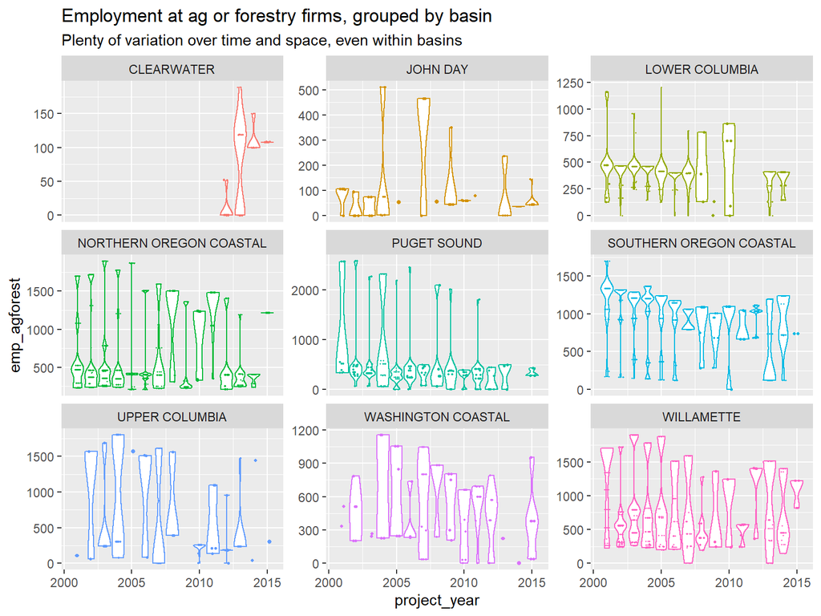

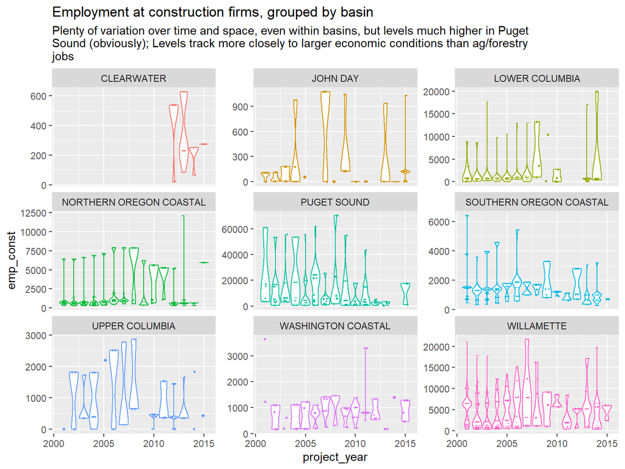

## Key takeaways

There are noticeable differences between Washington and Oregon culvert projects represented in the data. Washington projects tend to more frequently be on migration routes and on paved roads. Oregon projects are more likely to be on spawning and rearing streatms and unpaved roads. This likely goes a long way in explaining the large differences in costs across the two states.

## Questions and next steps

### Questions

1. StreamNet data provided only identifies one species. Are there overlapping species ranges? Could this column be provided as a list of species?
2. No descriptions of HERE road feature variables are provided. Where can these descriptions be found?

### Next steps

1. NHDPlus stream matches for all culverts in the Clearwater basin are missing, as well as all from the Salmon basin and almost all from the Spokane basin. NHDPlus data should be recovered for these regions.
2. Execute code to generate measures for…
1. Upstream habitat potential and other stream data from NHDPlus,
2. Nearest OSM road,
3. Density of nearby culvert work sites, and
4. ESU habitat ranges from HUC boundaries.
3. Clean up identification of “pure” culvert projects (i.e. projects that include non-culvert work in addition to culvert improvements).
4. Integrate new spatial data into cost models.

## End Matter

```r
# Created on...
Sys.time()
```

```
## [1] "2020-08-18 16:51:06 PDT"
```

```r
# Render output
# render(here("R/C.culvertsspatial/06.spatialexplore.R"), output_file = here("output/culvertsspatial_report_2020aug18.html"))
```